# Mobile Interactive app

Author

Joel John

Published

December 7, 2024

- [LINK to FIGMA](https://www.figma.com/file/YjmhlSGo7soEKjmE85gtM2/FOXHUB-STORYBOARD?type=design&node-id=0-1&mode=design&t=HjGeV3atsptoL8ZO-0)
- [LINK to Snack Editor](https://snack.expo.dev/@joyelljohn/foxhub)

# Overview of FoxHub

FoxHub is an innovative mobile application designed to serve as a comprehensive source for the latest news, weather updates, and FM radio entertainment. It aims to provide users with personalized news articles and headlines from around the world, alongside detailed weather forecasts and the ability to listen to local and national FM radio stations. The app features a user-friendly interface with a settings screen for personal customization, ensuring that users have control over their preferences for news, weather, and entertainment. By integrating with external APIs for weather data and possibly for news content, FoxHub ensures real-time accuracy and relevance. The app’s design focuses on ease of use, aiming to keep users informed and entertained through a single, seamless platform.

# Key features

Below are the key features:

- News Feed: Displays a list of news articles with headlines and thumbnails. Users can tap an article to read it in full.
- Weather: Provides detailed weather information. This screen is accessible via the app’s bottom navigation.
- FM Radio: Lists available FM radio stations. Users can select a station to start listening.
- Settings: Offers customization options for news preferences, weather settings, FM radio favorites, and notifications.

# Individual Screen details

Home Screen:

Description: This screen serves as the primary landing page of your app, displaying a list of news articles.

Features:

- Displays a list of news articles with a thumbnail and headline.
- Users can tap on an article to navigate to a detailed view.
- The screen layout includes a distinctive header with the app’s name.

Weather Screen:

Description: Provides current weather information and a forecast for Richmond, VA.

Features:

Description: Simulates an FM radio interface where users can select and play different radio channels.

Search Screen:

Description: Allows users to search for specific topics or articles.

Features:

- A search bar where users can input text.
- Displays a list of recommended search terms.
- Users can submit a search query or select a recommended term to see results.

Settings Screen:

Description: Provides various settings options for the app.

Features:

- Lists different settings like Account, Notifications, Preferences, and Contact Us.
- Tapping on a setting takes the user to a detailed settings page

## Main screen

The main screen serves as the central node for this application. All other screens return to this screen.

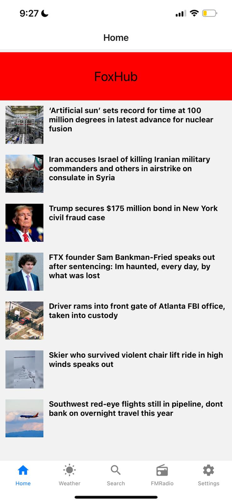

### Wireframe design

Below is my wireframe image

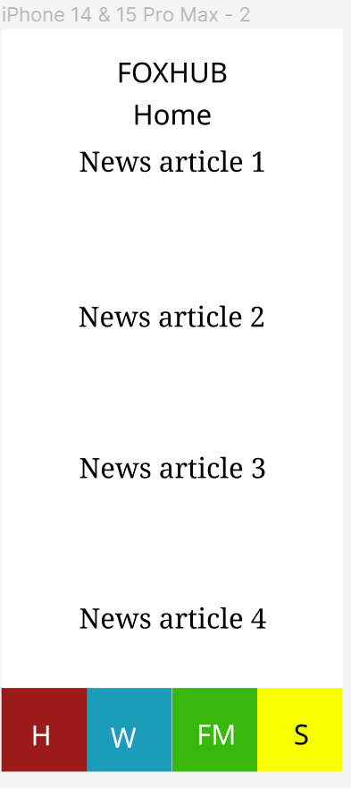

Home Screen

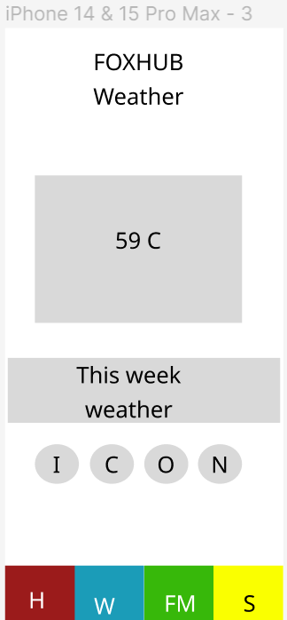

Weather Screen

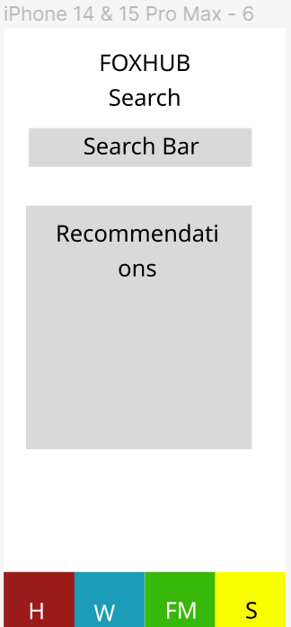

Search

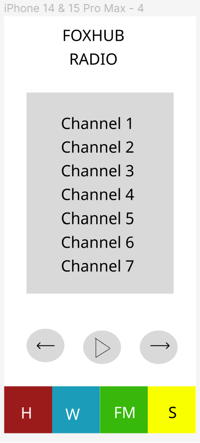

Radio

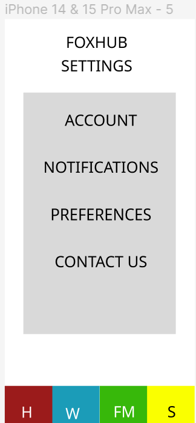

Settings

### As-built screenshot

Here is a screen shot of the image I created running on my phone.

[figure not shown]

Home Screen

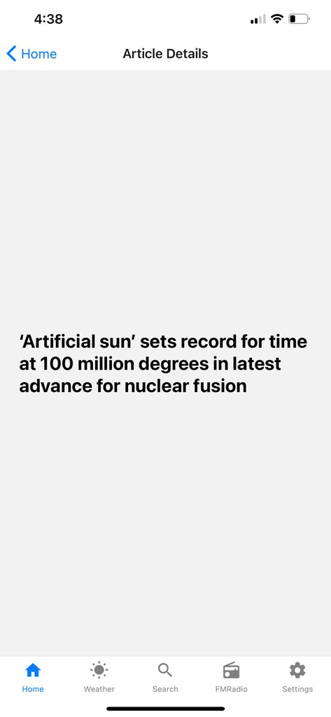

Interactivity for Home Screen

Home Screen:

Description: This screen serves as the primary landing page of your app, displaying a list of news articles.

Features:

- Displays a list of news articles with a thumbnail and headline.
- Users can tap on an article to navigate to a detailed view.
- The screen layout includes a distinctive header with the app’s name.

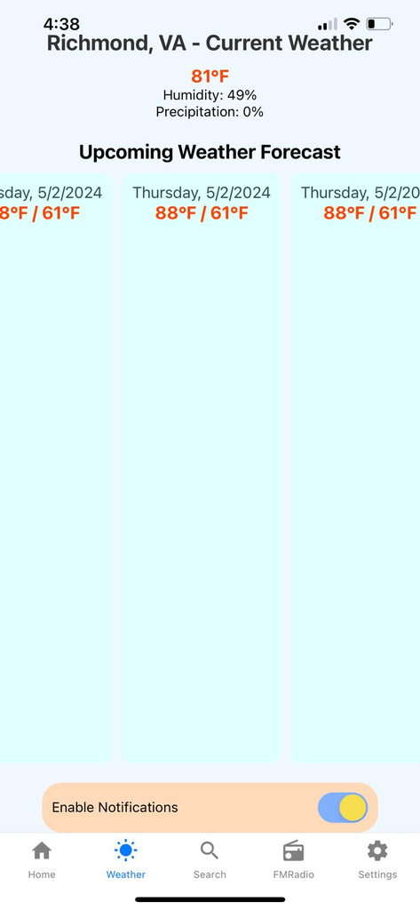

Interactivity for Weather Screen

Weather Screen:

Description: Provides current weather information and a forecast for Richmond, VA.

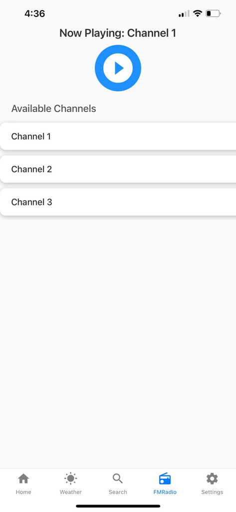

Interactivity for FM Radio Screen - play button

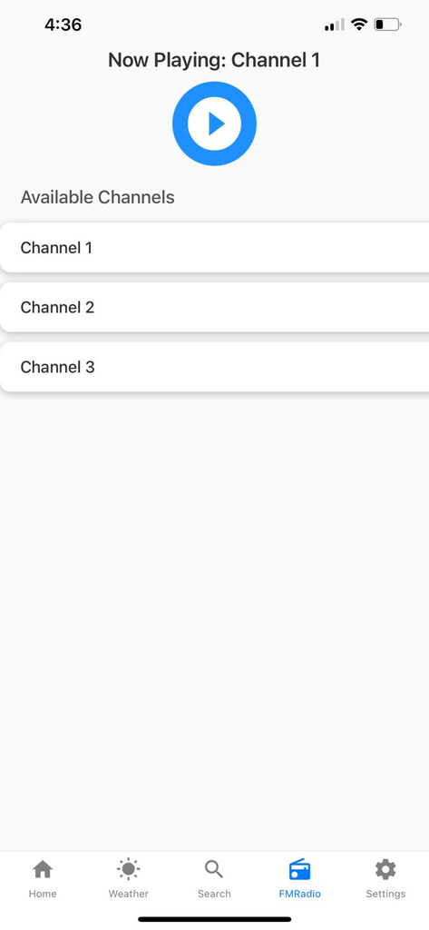

FM Radio Screen:

Description: Simulates an FM radio interface where users can select and play different radio channels.